# k = 2 Objective Landscape: fallback_emo_ace

Sam A. Sievertsen

2026-09-30

## Purpose

Bootstrap stability for this solution is bimodal: most resamples reproduce it almost exactly, while roughly 40% converge on a distinctly different partition. This report asks whether that alternative is a worse local optimum that refits sometimes fall into, or a competing solution of similar or better quality.

Every run below refits *k* = 2 on the **full** analytic sample, with the same data and the same λ as the primary fit, from a single random start (`nstart = 1`), so each run lands in whichever optimum its start leads to. Comparing the objective (total within-cluster distance, lower is better) and the agreement with the primary across 200 runs maps the landscape directly.

```r
## Many independent single-start refits on the full sample ##

#1. Configure workers, respecting the SLURM/cgroup allocation
n_workers <- max(1L, as.integer(parallelly::availableCores()))
if (n_workers > 1) plan(multicore, workers = n_workers) else plan(sequential)

#2. Refit from single random starts with the reference lambda held fixed
runs <- future_map(seq_len(params$n_runs), function(r) {
  set.seed(params$seed + r)
  fit <- kproto(x = kp_ref$data, k = 2, nstart = 1, lambda = kp_ref$lambda, keep.data = FALSE, verbose = FALSE)
  list(wss = fit$tot.withinss, cluster = fit$cluster, size = sort(fit$size))
}, .options = furrr_options(seed = TRUE))
plan(sequential)

#3. Summarize each run against the primary
run_tbl <- tibble(
  run = seq_along(runs),
  wss = map_dbl(runs, "wss"),
  ari_vs_primary = map_dbl(runs, ~ adjustedRandIndex(.x$cluster, kp_ref$cluster)),
  smaller_cluster_n = map_int(runs, ~ as.integer(.x$size[1]))
) %>%
  mutate(solution = case_when(
    ari_vs_primary > 0.99 ~ "Primary",
    TRUE ~ "Other"
  ))

#4. Group non-primary runs into distinct partitions (runs agreeing at ARI > 0.99 are the same partition)
other_idx <- which(run_tbl$solution == "Other")
partition_id <- rep(NA_integer_, nrow(run_tbl)); partition_id[run_tbl$solution == "Primary"] <- 0L
next_id <- 1L
for (i in other_idx) {
  if (!is.na(partition_id[i])) next
  same <- other_idx[vapply(other_idx, function(j) is.na(partition_id[j]) &&
                           adjustedRandIndex(runs[[i]]$cluster, runs[[j]]$cluster) > 0.99, logical(1))]
  partition_id[same] <- next_id; next_id <- next_id + 1L
}
run_tbl$partition <- ifelse(partition_id == 0L, "Primary", paste0("Alternative ", partition_id))

#5. Tabulate the distinct partitions found, ordered by objective
partitions <- run_tbl %>%
  group_by(partition) %>%
  summarise(runs_found = n(), pct_runs = 100 * n() / params$n_runs,
            best_wss = min(wss), median_ari_vs_primary = median(ari_vs_primary),
            smaller_cluster_n = as.integer(median(smaller_cluster_n)), .groups = "drop") %>%
  arrange(best_wss) %>%
  mutate(wss_minus_primary = best_wss - kp_ref$tot.withinss)

partitions %>%
  kable(caption = glue("Distinct k = 2 partitions reached from {params$n_runs} single random starts (primary WSS = {round(kp_ref$tot.withinss, 1)})"), digits = 3) %>%
  kable_styling(bootstrap_options = c("striped", "hover", "condensed", "responsive"))
```

Distinct k = 2 partitions reached from 200 single random starts (primary WSS = 156211.5)

| partition | runs_found | pct_runs | best_wss | median_ari_vs_primary | smaller_cluster_n | wss_minus_primary |
| --- | --- | --- | --- | --- | --- | --- |
| Primary | 35 | 17.5 | 156211.54 | 1.000 | 2072 | -0.004 |
| Alternative 1 | 32 | 16.0 | 156606.14 | 0.368 | 3008 | 394.602 |
| Alternative 3 | 29 | 14.5 | 157780.36 | 0.506 | 2392 | 1568.816 |
| Alternative 2 | 104 | 52.0 | 159088.13 | 0.295 | 3358 | 2876.592 |

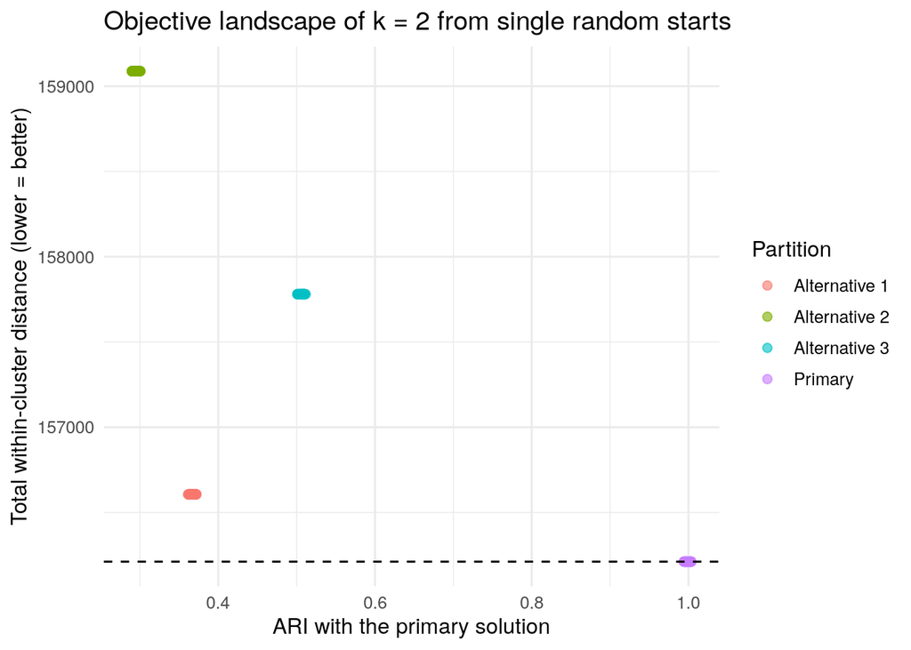

```r
write.csv(run_tbl, file.path(out_dir, sprintf("landscape_runs_%s.csv", params$config)), row.names = FALSE)

#6. Plot objective against agreement with the primary
ggplot(run_tbl, aes(x = ari_vs_primary, y = wss, color = partition)) +
  geom_jitter(width = 0.005, height = 0, alpha = 0.6, size = 2) +
  geom_hline(yintercept = kp_ref$tot.withinss, linetype = "dashed") +
  labs(x = "ARI with the primary solution", y = "Total within-cluster distance (lower = better)", color = "Partition",
       title = "Objective landscape of k = 2 from single random starts") +
  theme_minimal(base_size = 12)
```

## The Alternative Partition

The most frequently reached non-primary partition, characterized the same way as the primary.

```r
## Characterize the most common alternative partition ##

#1. Identify it, if any alternative was found
alt_name <- partitions %>% filter(partition != "Primary") %>% arrange(desc(runs_found)) %>% slice(1) %>% pull(partition)

if (length(alt_name) == 1) {

  #2. Take the best-objective run of that partition
  alt_run <- run_tbl %>% filter(partition == alt_name) %>% arrange(wss) %>% slice(1) %>% pull(run)
  alt_cl <- runs[[alt_run]]$cluster

  #3. Cross-tabulate against the primary
  print(kable(table(Primary = kp_ref$cluster, Alternative = alt_cl), caption = glue("Primary vs {alt_name} membership")) %>%
          kable_styling(bootstrap_options = c("striped", "hover", "condensed", "responsive")))

  #4. Mean silhouette of each partition, via the verified exact closed form
  kp_alt <- kp_ref; kp_alt$cluster <- alt_cl
  sil_tbl <- tibble(
    Partition = c("Primary", alt_name),
    WSS = c(kp_ref$tot.withinss, runs[[alt_run]]$wss),
    `Mean silhouette` = c(mean(silhouette_exact_huang(kp_ref)[, "sil_width"]), mean(silhouette_exact_huang(kp_alt)[, "sil_width"])),
    `Smaller cluster n` = c(min(table(kp_ref$cluster)), min(table(alt_cl))))
  print(kable(sil_tbl, caption = "Objective and silhouette of the two leading partitions", digits = 3) %>%
          kable_styling(bootstrap_options = c("striped", "hover", "condensed", "responsive")))

  #5. Feature profile of both partitions (d-equivalent, smaller cluster minus larger cluster)
  separation <- function(var, cl) {
    small <- as.integer(names(which.min(table(cl))))
    g <- factor(ifelse(cl == small, "Smaller", "Larger"), levels = c("Smaller", "Larger"))
    v <- raw[[var]]
    if (var %in% feats_categorical) {
      tab <- table(g, factor(v, levels = c(1, 0)))
      if (any(tab == 0)) return(NA_real_)
      as.numeric(effectsize::oddsratio_to_d(effectsize::oddsratio(tab)$Odds_ratio))
    } else {
      as.numeric(effectsize::cohens_d(v ~ g)$Cohens_d)
    }
  }
  prof <- tibble(feature = cluster_configs[[params$config]]) %>%
    mutate(Primary = map_dbl(feature, separation, cl = kp_ref$cluster),
           Alternative = map_dbl(feature, separation, cl = alt_cl)) %>%
    arrange(desc(abs(Alternative)))
  print(kable(prof, caption = glue("Feature separation (d-equivalent, smaller minus larger cluster): primary vs {alt_name}; sorted by the alternative"), digits = 2) %>%
          kable_styling(bootstrap_options = c("striped", "hover", "condensed", "responsive"), font_size = 11))
  write.csv(prof, file.path(out_dir, sprintf("landscape_alternative_profile_%s.csv", params$config)), row.names = FALSE)
} else {
  cat("No alternative partition was reached from any start.\n")
}
```

[output not shown]

[output cut: 109 more lines]

[output not shown]

## Summary

- **Primary reached from** 17.5% of single random starts; implied probability that `nstart = 8` reaches it: 78.5% (compare with the ~59% of bootstrap refits that reproduced it)
- **Best objective found:** Primary (WSS 156211.5; primary WSS 156211.5)
- **Reading:** the primary is the best partition found, but 8 starts reach it only part of the time, so the bootstrap alternative plausibly reflects refits that stopped in a worse local optimum; rerunning stability with more starts would test this